# BIOSTAT-M280: Homework #3

Due Mar 2nd @ 11:59PM

Darrick Shen (UID:604946049)

## Q1 LA City Employee Payroll

The `/home/m280-data/la_payroll/LA_City_Employee_Payroll.csv` file on teaching server contains payroll information of LA City employees in years 2013-2017. It was downloaded from [LA City Controller’s Office](https://controllerdata.lacity.org/Payroll/City-Employee-Payroll/pazn-qyym). Make a Shiny app to facilitate exploratory data analysis.

   The LA_City_Employee_Payroll.csv file was pre-processed, pared down, tidyed, and saved as the compressed RDS file LAPayroll.rds. For the subsequent parts please refer to the link to the published application.
2. **Total payroll by LA City**. Visualize the total LA City payroll of each year, with breakdown into base pay, overtime pay, and other pay.
3. **Who earned most?** Visualize the payroll information (total payment with breakdown into base pay, overtime pay, and other pay, Department, Job Title) of the top $n$ highest paid LA City employees in a specific year. User specifies $n$ (default 10) and year (default 2017).
4. **Which departments earn most?** Visualize the mean or median payroll, with breakdown into base pay, overtime pay, and other pay, of top $n$ earning departments. User specifies $n$ (default 5), year (default 2017), and method (mean or median, default median).
5. **Which departments cost most?** Visualize the total payroll, with breakdown into base pay, overtime pay, and other pay, of top $n$ expensive departments. User specifies $n$ (default 5) and year (default 2017).
6. Visualize any other information you are interested in.
7. Publish your Shiny app to https://www.shinyapps.io and share the link.

See the link below for my first Shiny app, investigating LA Employee Payroll Statistics: https://shendarrick821.shinyapps.io/myfirstshinyapp/

## Q2 LA City Parking War

The SQLite database `/home/m280-data/la_parking/LA_Parking_Citations.sqlite` on teaching server contains information about parking tickets in LA City. It was downloaded from [LA Open Data Portal](https://data.lacity.org/A-Well-Run-City/Parking-Citations/wjz9-h9np). Connect to the database and answer following questions using plots and summary statistics. In this exercise, you are **not** allowed to load whole data into memory. Use the *transform in database, plot in R* strategy.

1. How many tickets are in this data set? Which time period do these tickets span? Which years have most data?

   ```
   ## [1] "latix"
   ```

   ```sql
   SELECT
       count(DISTINCT Ticket_number)
   FROM
       latix
   ```

   1 records

   | count(DISTINCT Ticket_number) |
   | --- |
   | 4044338 |

   SQL code automatically removes the N/A ID results, leading to a 4,044,338 distinct ticket numbers. We can see from the total number of rows in the “latix” database, 4,044,488 rows represent the number of tickets, including those with a NA ID #

   ```r
     # Here we are displaying the top ticketed times.
   ascend <- latix_sql %>%
     filter(!is.na(Issue_Year)) %>%
     select(Issue_Year, Issue_Month, Issue_Month,
            Issue_Day, Issue_Hour, Issue_Minute) %>%
     arrange(Issue_Year, Issue_Month, Issue_Month,
             Issue_Day, Issue_Hour, Issue_Minute)
   head(ascend, n = 1)
   ```

   ```
   ## # Source:     lazy query [?? x 5]
   ## # Database:   sqlite 3.19.3
   ## #   [/home/m280-data/la_parking/LA_Parking_Citations_Extra.sqlite]
   ## # Ordered by: Issue_Year, Issue_Month, Issue_Month, Issue_Day, Issue_Hour,
   ## #   Issue_Minute
   ##   Issue_Year Issue_Month Issue_Day Issue_Hour Issue_Minute
   ##        <int>       <int>     <int>      <int>        <int>
   ## 1       2010           4        27         21           40
   ```

   ```r
     # Here we are displaying the lowest ticketed times.
   descend <- latix_sql %>%
   filter(!is.na(Issue_Year)) %>%
     select(Issue_Year, Issue_Month, Issue_Month,
            Issue_Day, Issue_Hour, Issue_Minute) %>%
     arrange(desc(Issue_Year), desc(Issue_Month), desc(Issue_Month),
             desc(Issue_Day), desc(Issue_Hour), desc(Issue_Minute))
   head(descend, n = 1)
   ```

   ```
   ## # Source:     lazy query [?? x 5]
   ## # Database:   sqlite 3.19.3
   ## #   [/home/m280-data/la_parking/LA_Parking_Citations_Extra.sqlite]
   ## # Ordered by: desc(Issue_Year), desc(Issue_Month), desc(Issue_Month),
   ## #   desc(Issue_Day), desc(Issue_Hour), desc(Issue_Minute)
   ##   Issue_Year Issue_Month Issue_Day Issue_Hour Issue_Minute
   ##        <int>       <int>     <int>      <int>        <int>
   ## 1       2017          12        30          1           41
   ```

   ```r
     # Here we are displaying the tickets issued each year.
   latix_sql %>%
     filter(!is.na(Issue_Year)) %>%
     group_by(Issue_Year) %>%
     summarize (n = n())
   ```

   ```
   ## # Source:   lazy query [?? x 2]
   ## # Database: sqlite 3.19.3
   ## #   [/home/m280-data/la_parking/LA_Parking_Citations_Extra.sqlite]
   ##   Issue_Year       n
   ##        <int>   <int>
   ## 1       2010      10
   ## 2       2011      10
   ## 3       2012      29
   ## 4       2013      38
   ## 5       2014   39206
   ## 6       2015 2161119
   ## 7       2016 1763273
   ## 8       2017   29719
   ```

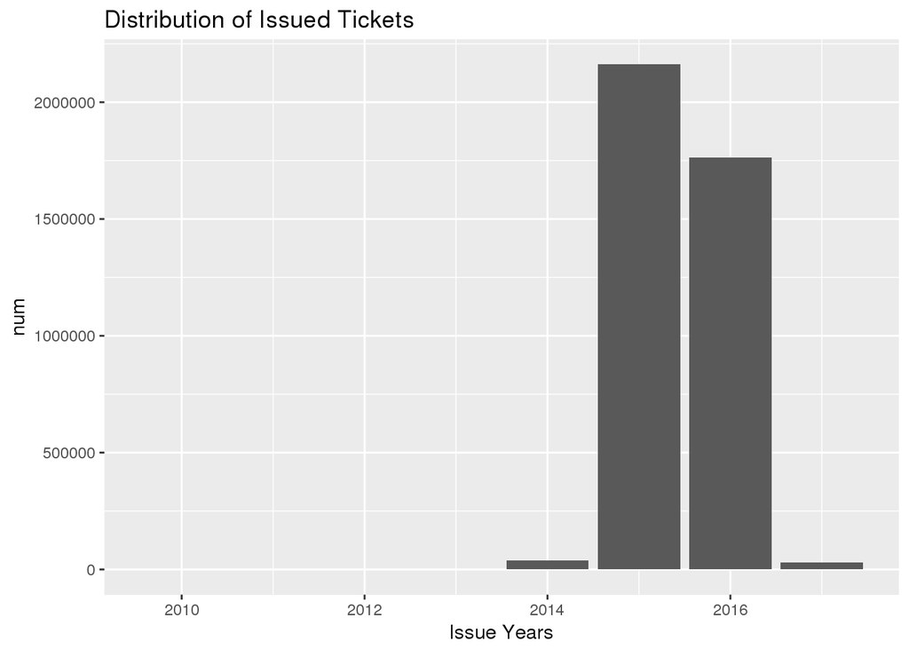

   ```r
   latix_sql %>%
     group_by(Issue_Year) %>%
     filter(!is.na(Issue_Year)) %>%
     summarise(num = n()) %>%
     collect() %>%
     ggplot() +
       geom_col(aes(x = Issue_Year, y = num)) +
       scale_x_continuous("Issue Years") +
       ggtitle("Distribution of Issued Tickets")
   ```

   There are 4044338 distinct ticket numbers. In addition 150 tickets had a NA ticket ID. The oldest issued ticket was on 2010-04-27, at 21:40, while the most recently issued ticket was on 2017-12-30, at 01:41. The most tickets were issued in 2015 (2,161,119 tickets).
2. When (which hour, weekday, month day, and month) are you most likely to get a ticket and when are you least likely to get a ticket?

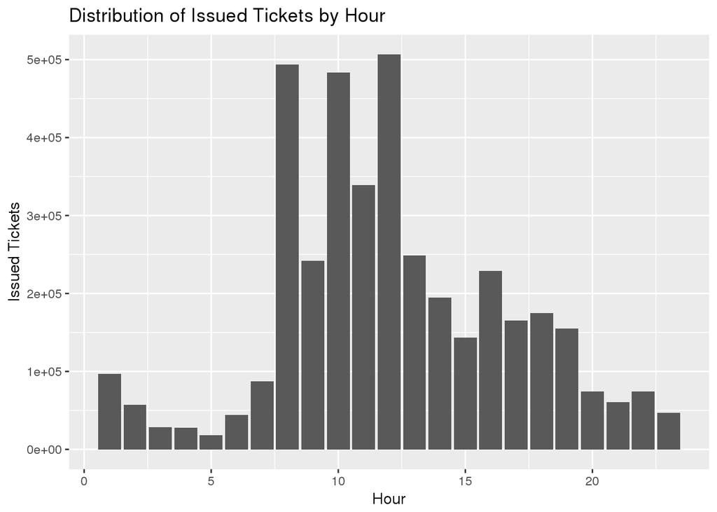

   ```r
   latix_sql %>%
     group_by(Issue_Hour) %>%
     filter(!is.na(Issue_Hour)) %>%
     summarise(num = n()) %>%
     collect() %>%
     ggplot() +
       geom_col(aes(x = Issue_Hour, y = num)) +
       ggtitle("Distribution of Issued Tickets by Hour") +
       xlab("Hour") +
       ylab("Issued Tickets")
   ```

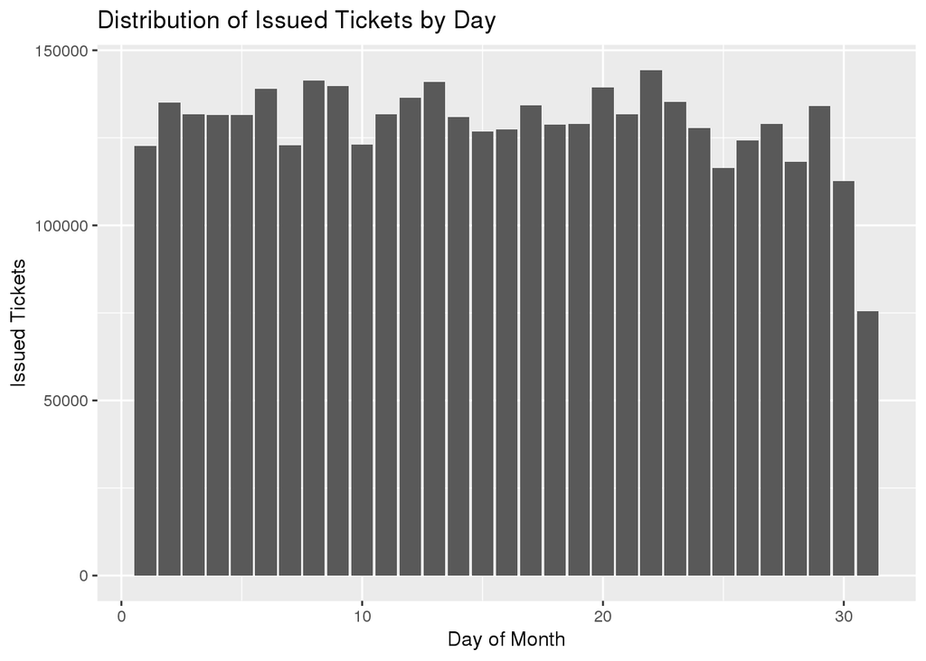

   ```r
   latix_sql %>%
     group_by(Issue_Day) %>%
     filter(!is.na(Issue_Day)) %>%
     summarise(num = n()) %>%
     collect() %>%
     ggplot() +
       geom_col(aes(x = Issue_Day, y = num)) +
       ggtitle("Distribution of Issued Tickets by Day") +
       xlab("Day of Month") +
       ylab("Issued Tickets")
   ```

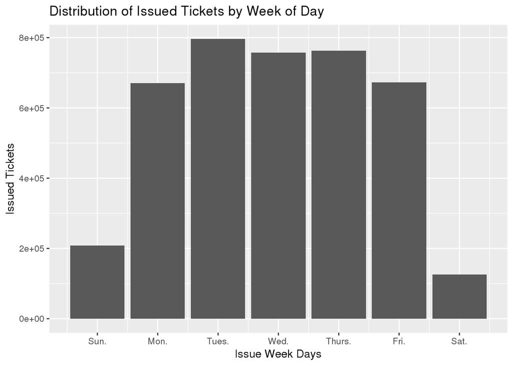

   ```r
   latix_sql %>%
     group_by(Issue_Wday) %>%
     filter(!is.na(Issue_Wday)) %>%
     summarise(num = n()) %>%
     collect() %>%
     ggplot() +
       geom_col(aes(x = Issue_Wday, y = num)) +
       scale_x_continuous("Issue Week Days",
                          breaks = c(1, 2, 3, 4, 5, 6, 7),
                                     label = c("Sun.", "Mon.",
                                               "Tues.", "Wed.",
                                               "Thurs.", "Fri.",
                                               "Sat.")) +
       ggtitle("Distribution of Issued Tickets by Week of Day") +
       xlab("Day of Week") +
       ylab("Issued Tickets")
   ```

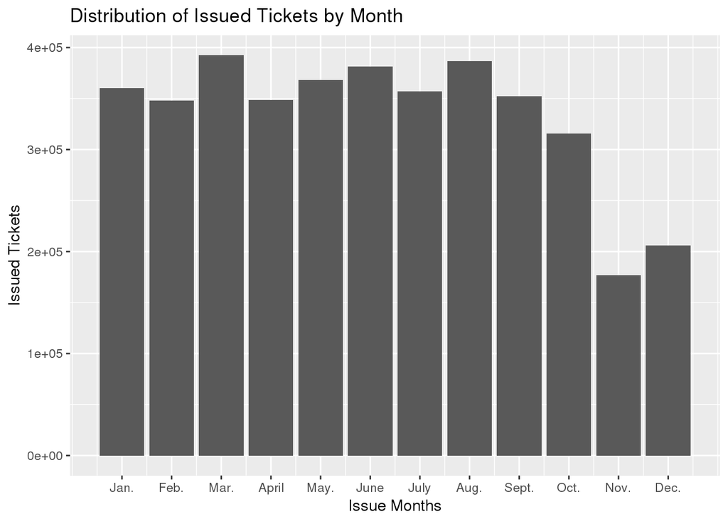

   ```r
   latix_sql %>%
     group_by(Issue_Month) %>%
     filter(!is.na(Issue_Month)) %>%
     summarise(num = n()) %>%
     collect() %>%
     ggplot() +
       geom_col(aes(x = Issue_Month, y = num)) +
       scale_x_continuous("Issue Months",
                          breaks = c(1, 2, 3, 4, 5, 6, 7, 8, 9, 10, 11, 12),
                          label = c("Jan.", "Feb.", "Mar.", "April", "May.",
                                    "June", "July", "Aug.", "Sept.", "Oct.",
                                    "Nov.", "Dec.")) +
       ggtitle("Distribution of Issued Tickets by Month") +
       xlab("Month") +
       ylab("Issued Tickets")
   ```

   ```r
     # Most Ticketed Hour.
   latix_sql %>%
     filter(!is.na(Issue_Hour)) %>%
     count(Issue_Hour) %>%
     arrange(n) %>%
     collect() %>%
     head(1) %>%
     kable()
   ```

   | Issue_Hour | n |
   | --- | --- |
   | 5 | 18317 |

   ```r
    # Least Ticketed Hour.
      latix_sql %>%
    filter(!is.na(Issue_Hour)) %>%
    count(Issue_Hour) %>%
    arrange(n) %>%
    collect() %>%
    tail(1) %>%
    kable()
   ```

   | Issue_Hour | n |
   | --- | --- |
   | 12 | 506580 |

   ```r
     # Most ticketed day.
   latix_sql %>%
     filter(!is.na(Issue_Day)) %>%
     count(Issue_Day) %>%
     arrange(n) %>%
     collect() %>%
     head(1) %>%
     kable()
   ```

   | Issue_Day | n |
   | --- | --- |
   | 31 | 75464 |

   ```r
    #  Least ticketed day.
   latix_sql %>%
     filter(!is.na(Issue_Day)) %>%
     count(Issue_Day) %>%
     arrange(n) %>%
     collect() %>%
     tail(1) %>%
     kable()
   ```

   | Issue_Day | n |
   | --- | --- |
   | 22 | 144331 |

   ```r
     # Most ticketed month.
   latix_sql %>%
     filter(!is.na(Issue_Month)) %>%
     count(Issue_Month) %>%
     arrange(n) %>%
     collect() %>%
     head(1) %>%
     kable()
   ```

   | Issue_Month | n |
   | --- | --- |
   | 11 | 177039 |

   ```r
     # Least ticketed month.
   latix_sql %>%
     filter(!is.na(Issue_Month)) %>%
     count(Issue_Month) %>%
     arrange(n) %>%
     collect() %>%
     tail(1) %>%
     kable()
   ```

   | Issue_Month | n |
   | --- | --- |
   | 3 | 392473 |

   ```r
     # Most ticketed day of the week.
   latix_sql %>%
     filter(!is.na(Issue_Wday)) %>%
     count(Issue_Wday) %>%
     arrange(n) %>%
     collect() %>%
     head(1) %>%
     kable()
   ```

   | Issue_Wday | n |
   | --- | --- |
   | 7 | 125327 |

   ```r
     # Least ticketed day of the week.
   latix_sql %>%
     filter(!is.na(Issue_Wday)) %>%
     count(Issue_Wday) %>%
     arrange(n) %>%
     collect() %>%
     tail(1) %>%
     kable()
   ```

   | Issue_Wday | n |
   | --- | --- |
   | 3 | 796643 |

   The most likely hour is 12 (noon), while the least likely hour 5 (AM).  
   The most likely month day is 22, while the least likely month day is 31.  
   The most likely weekday is Tuesday, while the least likely weekday is Saturday.  
   The most likely Month is March, while the least likely month is Novemeber.
3. Which car makes received most citations?

   ```r
   latix_sql %>%
     group_by(Make) %>%
       tally() %>%
       collect() %>%
       filter(n == max(n)) %>%
       arrange(desc(n))
   ```

   ```
   ## # A tibble: 1 x 2
   ##   Make       n
   ##   <chr>  <int>
   ## 1 TOYT  669548
   ```

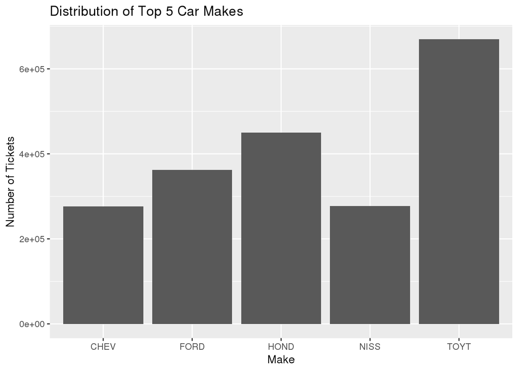

   ```r
   # plot of cars with most cars;
     latix_sql %>%
       group_by(Make) %>%
       summarise(num = n()) %>%
       arrange(desc(num)) %>%
       collect() %>%
       top_n(5) %>%
       ggplot() +
         geom_col(aes(x = Make, y = num)) +
         ggtitle("Distribution of Top 5 Car Makes") +
         ylab("Number of Tickets")
   ```

   ```r
     latix_sql %>%
       group_by(Make) %>%
       filter( Make == "TOYO") %>%
       summarise(num = n()) %>%
       arrange(desc(num)) %>%
       collect() %>%
         kable()
   ```

   | Make | num |
   | --- | --- |
   | TOYO | 39180 |

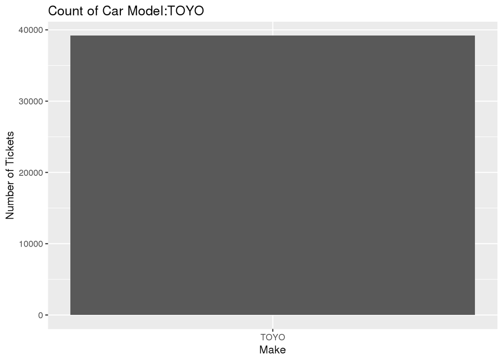

   ```r
   latix_sql %>%
     group_by(Make) %>%
     filter(Make == "TOYO") %>%
     summarise(num = n()) %>%
     arrange(desc(num)) %>%
     collect() %>%
     ggplot() +
       geom_col(aes(x = Make, y = num)) +
       ggtitle("Count of Car Model:TOYO") +
       ylab("Number of Tickets")
   ```

Toyota (TOYT) recieved the most citations at 669,548. We also notice 39,180 “TOYO” makes, which is likely also Toyota vehicles.

4. How many different colors of cars were ticketed? Which color attracted most tickets?

   ```sql
   SELECT
       count(DISTINCT Color)
   FROM
       latix
   ```

   1 records

   | count(DISTINCT Color) |
   | --- |
   | 65 |

   There are 65 different colors of cars ticketed.

   ```r
   latix_sql %>%
     group_by(Color) %>%
     tally() %>%
     collect() %>%
     filter(n == max(n)) %>%
     arrange(desc(n)) %>%
     kable()
   ```

   | Color | n |
   | --- | --- |
   | BK | 862283 |

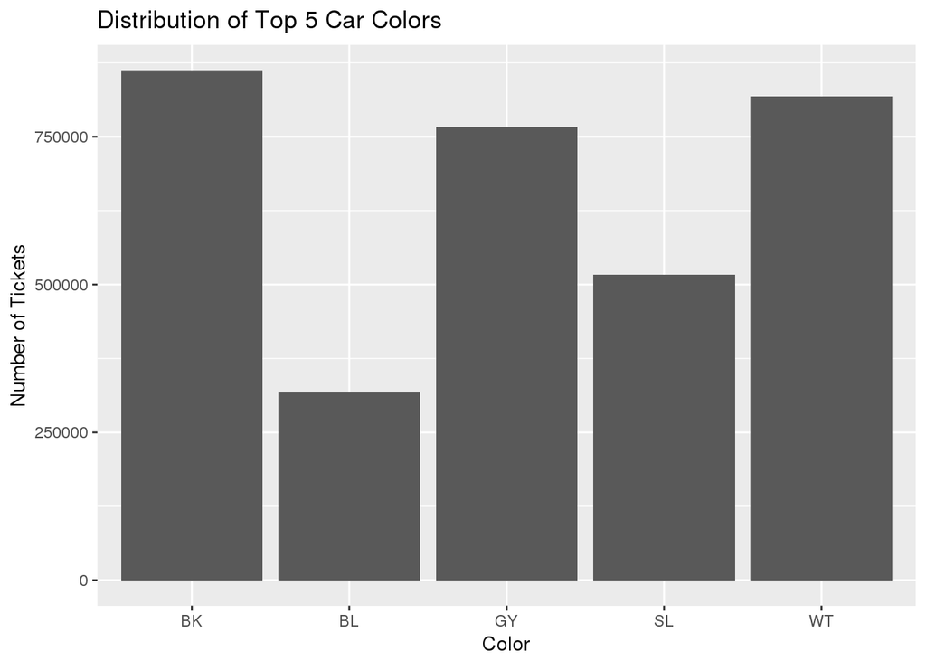

   ```r
   latix_sql %>%
     group_by(Color) %>%
     summarise(num = n()) %>%
     arrange(desc(num)) %>%
     collect() %>%
     top_n(5) %>%
     ggplot() +
       geom_col(aes(x = Color, y = num)) +
       ggtitle("Distribution of Top 5 Car Colors") +
       ylab("Number of Tickets")
   ```

Black color vehicles attracted the most tickets, indicated by Color “BK” having the most tickets (862,283).

5. What are the most common ticket types?

   ```r
   latix_sql %>%
     group_by(Violation_Description) %>%
     tally() %>%
     collect() %>%
     filter(n == max(n)) %>%
     arrange(desc(n)) %>%
     kable()
   ```

   | Violation_Description | n |
   | --- | --- |
   | NO PARK/STREET CLEAN | 1149021 |

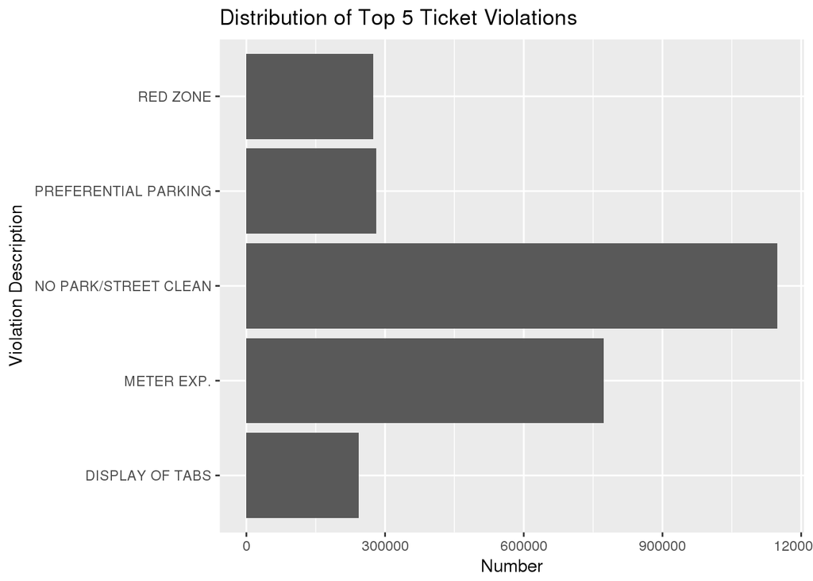

   ```r
   latix_sql %>%
     group_by(Violation_Description) %>%
     summarise(num = n()) %>%
     arrange(desc(num)) %>%
     collect() %>%
     top_n(5) %>%
     ggplot() +
       geom_col(aes(x = Violation_Description, y = num)) +
       xlab("Violation Description") + ylab("Number") +
       coord_flip() +
       ggtitle("Distribution of Top 5 Ticket Violations")
   ```

The most common ticket type was “NO PARK/STREET CLEAN”, with a total of 1,149,021 tickets.

6. How much money was collected on parking tickets in 2015 and 2016?

   ```r
   latix_sql %>%
     select(Issue_Year, Fine_amount) %>%
     filter(Issue_Year == 2016 | Issue_Year == 2015) %>%
     group_by(Issue_Year) %>%
     summarize(totalfine = sum(Fine_amount, na.rm = TRUE)) %>%
     kable(col.names = c("Issue Year ", "   Total Fine Amount ($)"))
   ```

   | Issue Year | Total Fine Amount ($) |
   | --- | --- |
   | 2015 | 151006794 |
   | 2016 | 123236136 |

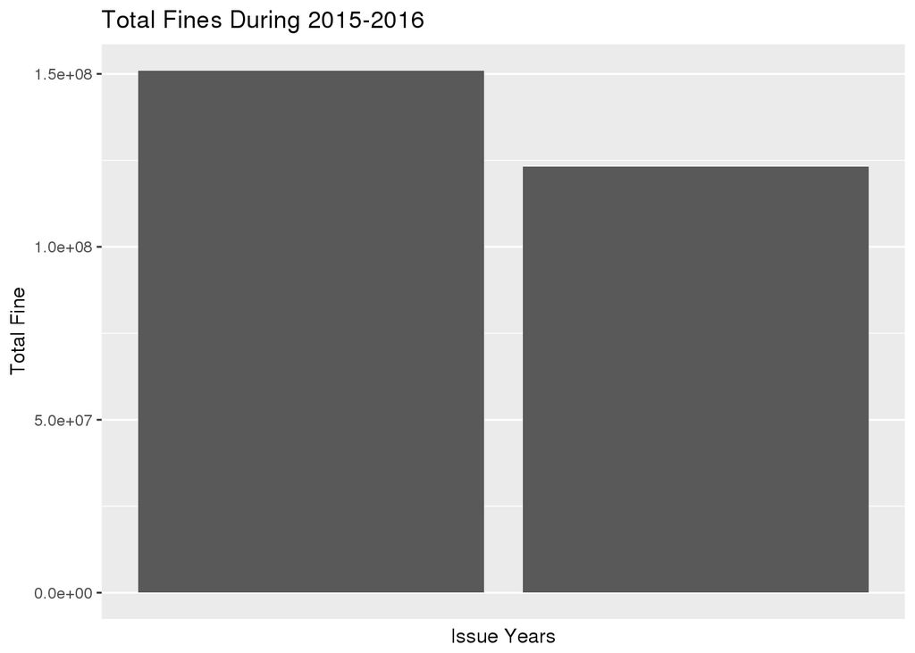

   ```r
   latix_sql %>%
     select(Issue_Year, Fine_amount) %>%
     filter(Issue_Year == 2016 | Issue_Year == 2015) %>%
     group_by(Issue_Year) %>%
     summarize(totalfine = sum(Fine_amount, na.rm = TRUE)) %>%
     collect() %>%
     ggplot() +
       geom_col(aes(x = Issue_Year, y = totalfine)) +
       scale_x_continuous("Issue Years", breaks = c(1, 2),
                    label = c("2015", "2016")) +
                    ggtitle("Total Fines During 2015-2016") +
                    labs( y = "Total Fine")
   ```

The total fine amount in 2015 was 151,006,794 dollars, and the total fine amount in 2016 was 123,236,136 dollars.

7. Visualize any other information you are interested in.

   ```r
   latix_sql %>%
     group_by(RP_State_Plate) %>%
     summarise(num = n()) %>%
     arrange(desc(num)) %>%
     collect() %>%
     top_n(7) %>%
     kable(col.names = c("License Plate State", "Number of Tickets"),
           align = "l")
   ```

   | License Plate State | Number of Tickets |
   | --- | --- |
   | CA | 3766908 |
   | AZ | 36089 |
   | TX | 25845 |
   | NV | 24709 |
   | FL | 16800 |
   | WA | 16008 |
   | IL | 11920 |

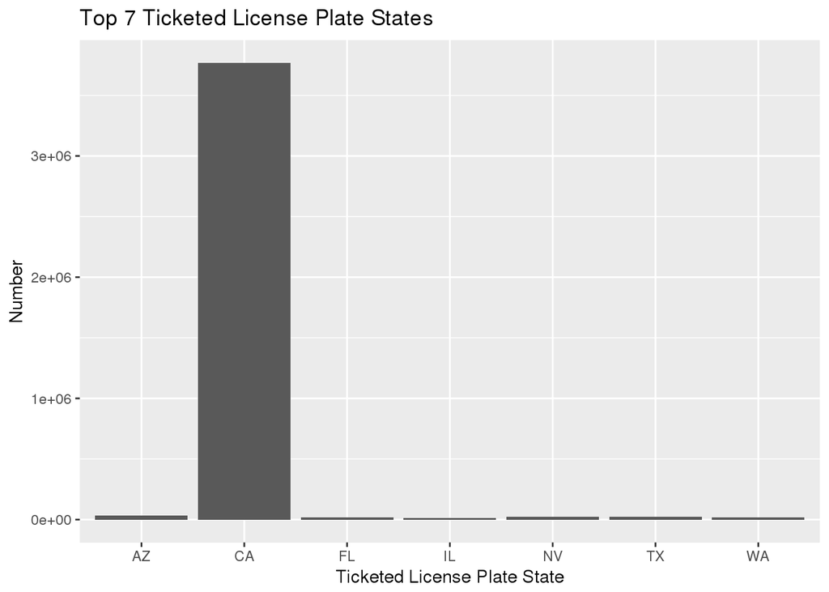

   ```r
   latix_sql %>%
     group_by(RP_State_Plate) %>%
     summarise(num = n()) %>%
     arrange(desc(num)) %>%
     collect() %>%
     top_n(7) %>%
     ggplot() +
       geom_col(aes(x = RP_State_Plate, y = num)) +
       ggtitle("Top 7 Ticketed License Plate States") +
       xlab("Ticketed License Plate State") +
       ylab("Number")
   ```

California is the most frequently ticketed license plate at 3,766,908 times, with the most ticketed out-of-state licenses being Arizona, Texas, and Nevada, in descending order.